# ggplot_HandsOn

### Use shape to highlight the different penguin species

Let’s map the variable “species” to the aesthetic “shape”.

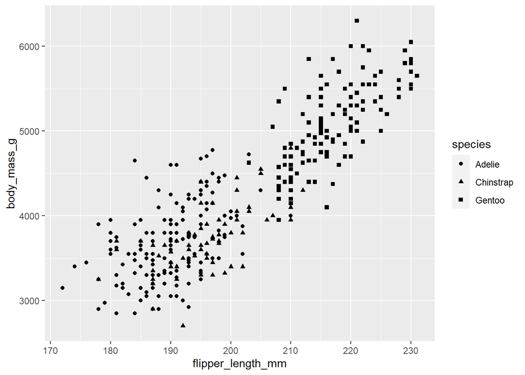

```r
ggplot(data = penguins)+
  geom_point(mapping = aes(x=flipper_length_mm, y=body_mass_g,shape=species))
```

### Map more than one aesthetic to the same variable

Let’s map both color and shape to species

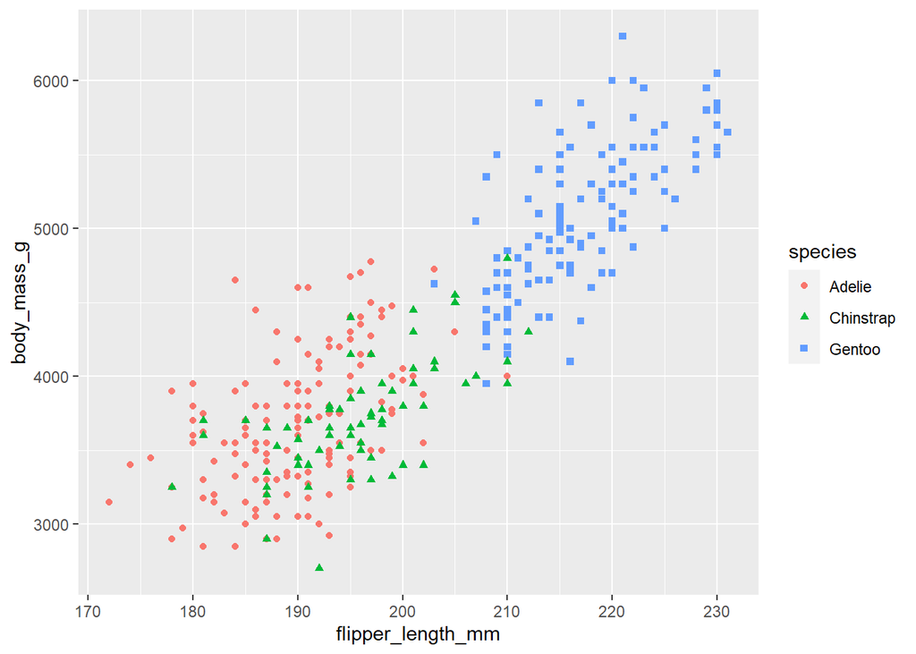

```r
ggplot(data = penguins)+
  geom_point(mapping = aes(x=flipper_length_mm, y=body_mass_g,shape=species, color=species))
```

### Map the alpha aesthetic to species

This is an option for those who like black and white plot. This will make some points more transparent or see-through than others. This gives us another way to represent each penguin species.

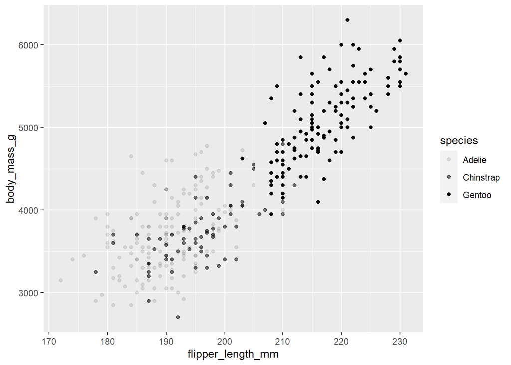

```r
ggplot(data = penguins)+
  geom_point(mapping = aes(x=flipper_length_mm, y=body_mass_g,alpha=species))
```

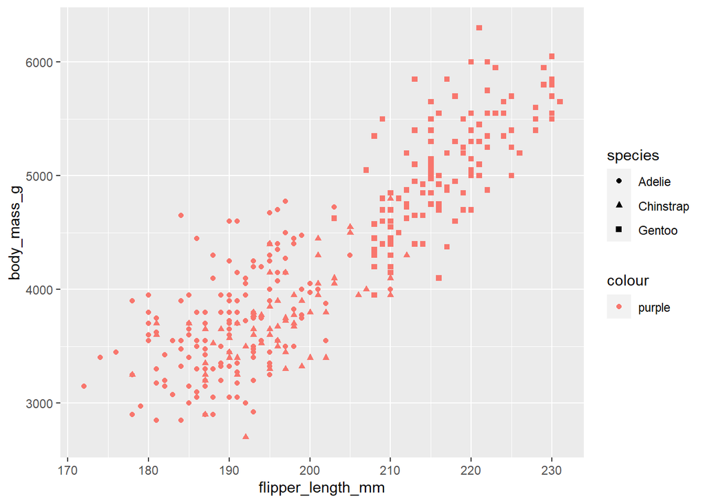

```r
ggplot(data = penguins)+
  geom_point(mapping = aes(x=flipper_length_mm, y=body_mass_g,shape=species, color="purple"))
```

### Write code outside of the aes function

Purpose: change the appearance of our overall plot without regard to specific variables.

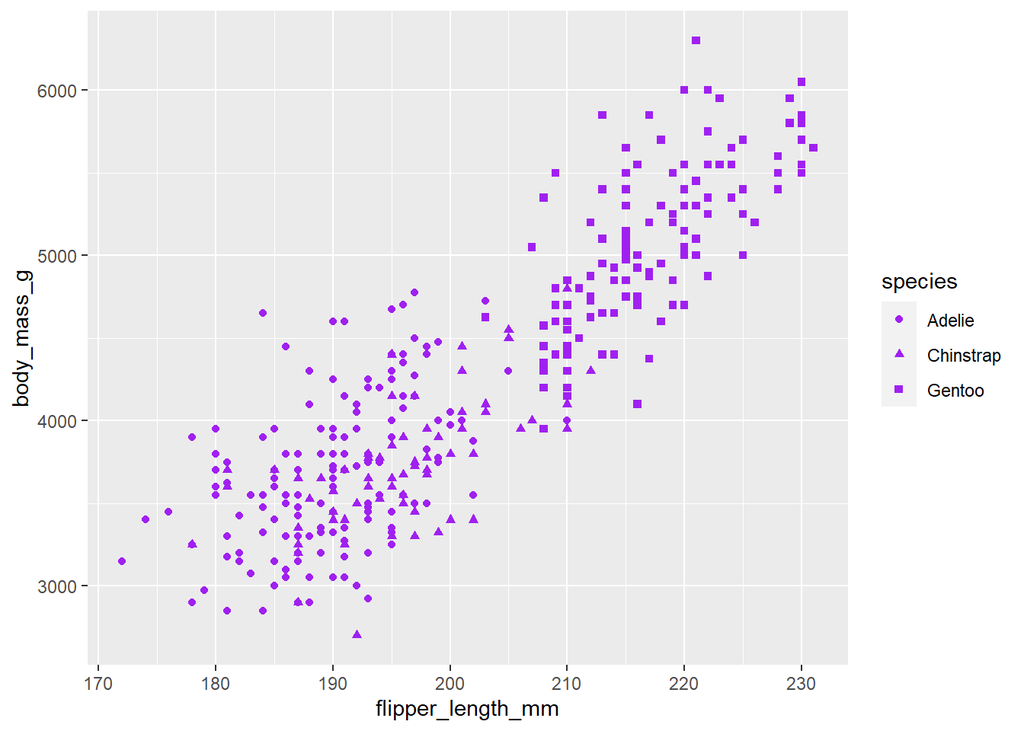

```r
ggplot(data = penguins)+
  geom_point(mapping = aes(x=flipper_length_mm, y=body_mass_g,shape=species), color="purple")
```

We have the same data but with different visual appearance:

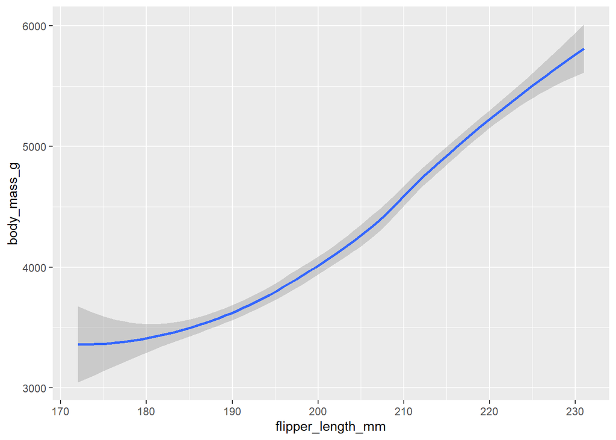

```r
ggplot(data = penguins)+
  geom_smooth(mapping = aes(x=flipper_length_mm, y=body_mass_g))
```

### Use 2 geoms in the same plot

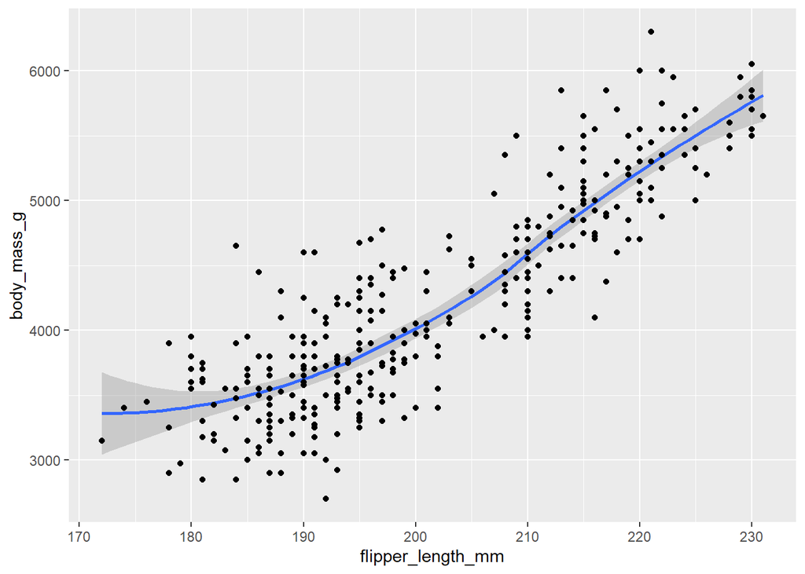

```r
ggplot(data = penguins)+
  geom_smooth(mapping = aes(x=flipper_length_mm, y=body_mass_g)) +
  geom_point(mapping = aes(x=flipper_length_mm, y=body_mass_g))
```

### Geom_smooth

We can add the line type aesthetic and map it to the variable species. Geom_smooth will draw a different line with a different line type for each species. The plot shows the trend for each species of penguins.

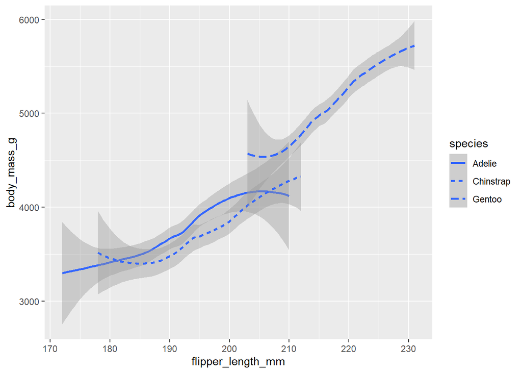

```r
ggplot(data = penguins)+
  geom_smooth(mapping = aes(x=flipper_length_mm, y=body_mass_g, linetype=species))
```